# Project: football Team Attendance Variety and Ifootballuencing Factors

## Clustering Analysis

### Goal

Cluster the teams by related features and find similar patterns of teams with similar home attendance rates, as well as distinguishing the difference between different clusters.

### Steps

- Agglomerative Clustering
- K-Means Clustering

### Agglomerative Clustering

Clustering groups data based on similarity without prior labels (unsupervised).

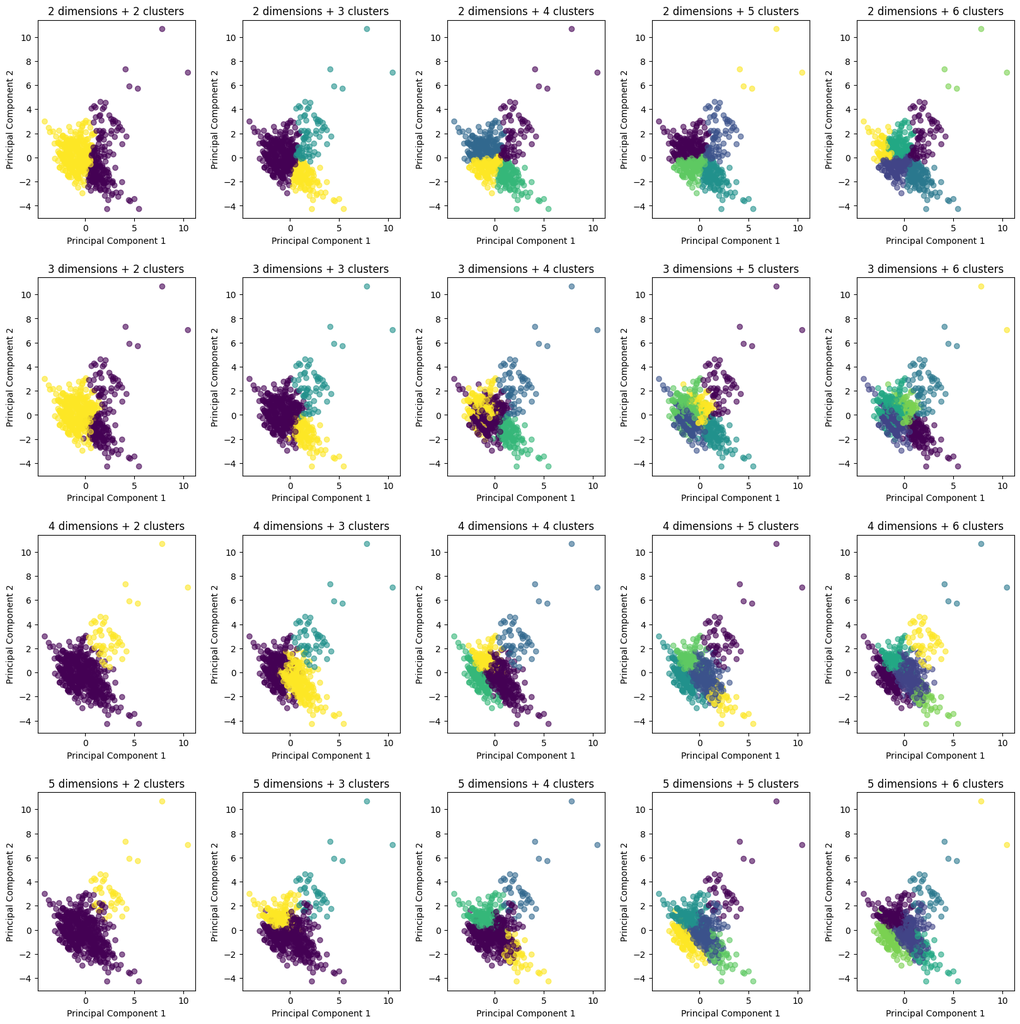

```python
# fit the Agglomerative Clustering model with different number of clusters
np.random.seed(0)
agg_clustering_2 = AgglomerativeClustering(n_clusters=2)
agg_clustering_3 = AgglomerativeClustering(n_clusters=3)
agg_clustering_4 = AgglomerativeClustering(n_clusters=4)
agg_clustering_5 = AgglomerativeClustering(n_clusters=5)
agg_clustering_6 = AgglomerativeClustering(n_clusters=6)

# implement a function to plot the scatterplot with different number of clusters and dimensions
def plot_cluster(dimension, clusters):
    plt.scatter(dimension[:, 0], dimension[:, 1], c=clusters.fit_predict(dimension), alpha=0.6) # plot the first two dimensions
    plt.title(f'{dimension.shape[1]} dimensions + {clusters.n_clusters} clusters')


# plot the scatterplot with different number of clusters and dimensions
plt.figure(figsize=(20, 20))
dimensions = [X_pca_2, X_pca_3, X_pca_4, X_pca_5]
clusters = [agg_clustering_2, agg_clustering_3, agg_clustering_4, agg_clustering_5, agg_clustering_6]
for i in range(4):
    for j in range(5):
        plt.subplot(4, 5, i * 5 + j + 1)
        plt.xlabel("Principal Component 1")
        plt.ylabel("Principal Component 2")
        # adjust the space between the subplots
        plt.subplots_adjust(hspace=0.3, wspace=0.3)
        plot_cluster(dimensions[i], clusters[j])

plt.show()
```

Among all plots of different dimensions and clusters, the plot of 2 dimensions plus 5 clusters seems to be the most appropriate. The plot of 2 dimensions + 5 clusters minimizes intra-cluster distances and shows the least overlap between different clusters. Analysis also benefits from grouping outliers into a single cluster.

```python
# create cluster labels
cluster_labels = agg_clustering_5.fit_predict(X_pca_2)
# concat the cluster labels with the original data
football_clustered = pd.concat([pd.DataFrame(cluster_labels).reset_index(),football.reset_index()],axis=1).drop('index',axis=1)
football_clustered.rename(columns={0:'cluster'},inplace=True)

# check the cluster labels
football_clustered.head()
```

|  | cluster | team_id | wins | loss | win_percentage | win_percentage_category | playoffs | superbowl_winner | state | county | gdp_chained_million_dollar | gdp_category | stadium_capacity | renovated | home_attendance_per_game | home_attendance_rate_per_game | home_attendance_rate_category |
| --- | --- | --- | --- | --- | --- | --- | --- | --- | --- | --- | --- | --- | --- | --- | --- | --- | --- |
| 0 | 2 | Cardinals_2001 | 7 | 9 | 0.44 | low | False | 0 | Arizona | Maricopa | 145484.0 | medium | 73379.0 | False | 38414.375 | 0.523506 | low |
| 1 | 2 | Cardinals_2002 | 5 | 11 | 0.31 | low | False | 0 | Arizona | Maricopa | 150559.0 | medium | 73379.0 | False | 40909.000 | 0.557503 | low |
| 2 | 2 | Cardinals_2003 | 4 | 12 | 0.25 | low | False | 0 | Arizona | Maricopa | 160947.0 | medium | 73379.0 | False | 36062.375 | 0.491454 | low |
| 3 | 2 | Cardinals_2004 | 6 | 10 | 0.38 | low | False | 0 | Arizona | Maricopa | 169495.0 | medium | 71706.0 | False | 37533.375 | 0.523434 | low |
| 4 | 2 | Cardinals_2005 | 5 | 11 | 0.31 | low | False | 0 | Arizona | Maricopa | 184185.0 | medium | 71706.0 | False | 50129.375 | 0.699096 | low |

```python
football_clustered['cluster'].value_counts()
```

```
cluster
0    203
3    178
2    129
1     74
4      5
Name: count, dtype: int64
```

```python
# Remove outliers for win_percentage, gdp, and home_attendance_rate for each cluster for each cluster

features_to_clean = ['win_percentage', 'gdp_chained_million_dollar', 'home_attendance_rate_per_game']

# Get the unique clusters
clusters = football_clustered['cluster'].unique()

# Create a new DataFrame to store the non-outliers
non_outliers_df = pd.DataFrame()

for cluster in clusters:
    cluster_data = football_clustered[football_clustered['cluster'] == cluster]
    cluster_mask = pd.Series(True, index=cluster_data.index)

    for feature in features_to_clean:
        # Calculate Q1, Q3 and IQR for each feature within the current cluster
        Q1 = cluster_data[feature].quantile(0.25)
        Q3 = cluster_data[feature].quantile(0.75)
        IQR = Q3 - Q1

        feature_mask = ((cluster_data[feature] >= (Q1 - 1.5 * IQR)) &
                        (cluster_data[feature] <= (Q3 + 1.5 * IQR))) # Create a mask for the current feature (Applied CHATGPT to help with the code)
        cluster_mask &= feature_mask # Combine the masks for all features

    non_outliers_df = pd.concat([non_outliers_df, cluster_data[cluster_mask]], axis=0) # Append the non-outliers to the new DataFrame

football_clustered = non_outliers_df
```

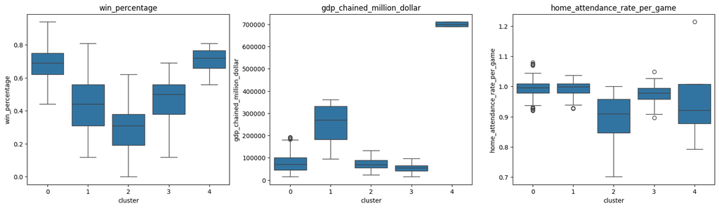

```python
# check the distribution of win_percentage, gdp, and home_attendance_rate for each cluster
plt.figure(figsize=(20, 5))

plt.subplot(1, 3, 1)
sns.boxplot(x='cluster', y='win_percentage', data=football_clustered)
plt.title('win_percentage')

plt.subplot(1, 3, 2)
sns.boxplot(x='cluster', y='gdp_chained_million_dollar', data=football_clustered)
plt.title('gdp_chained_million_dollar')

plt.subplot(1, 3, 3)
sns.boxplot(x='cluster', y='home_attendance_rate_per_game', data=football_clustered)
plt.title('home_attendance_rate_per_game')

plt.show()
```

**win_percentage**